# 11 An Introduction to Descriptive Statistics

Consider the following histogram.

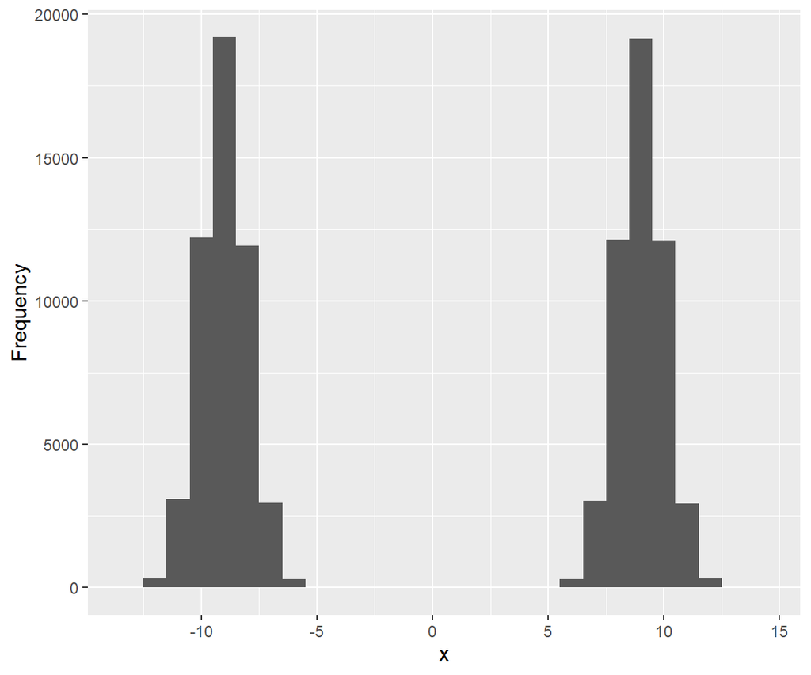

1. Describe the modality of the histogram.
2. Describe the symmetry of the histogram.
3. Describe the skewness of the histogram.

(Question ID: *0038705516*)

Consider the following histogram.

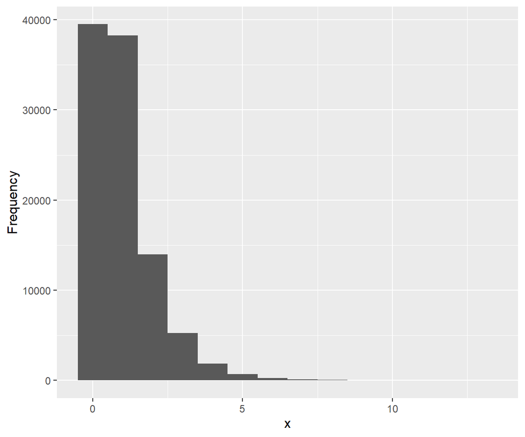

1. Describe the modality of the histogram.
2. Describe the symmetry of the histogram.
3. Describe the skewness of the histogram.

(Question ID: *0854080178*)

Consider the following histogram.

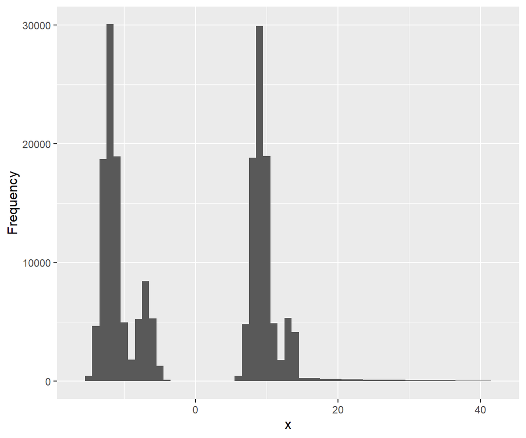

1. Describe the modality of the histogram.
2. Describe the symmetry of the histogram.
3. Describe the skewness of the histogram.

(Question ID: *0828128712*)

Consider the following histogram.

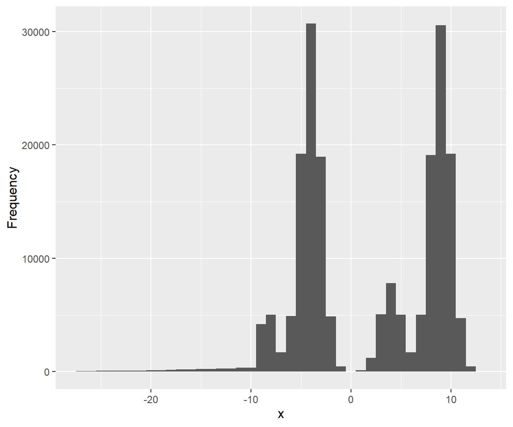

1. Describe the modality of the histogram.
2. Describe the symmetry of the histogram.
3. Describe the skewness of the histogram.

(Question ID: *0272023988*)

Consider the following histogram.

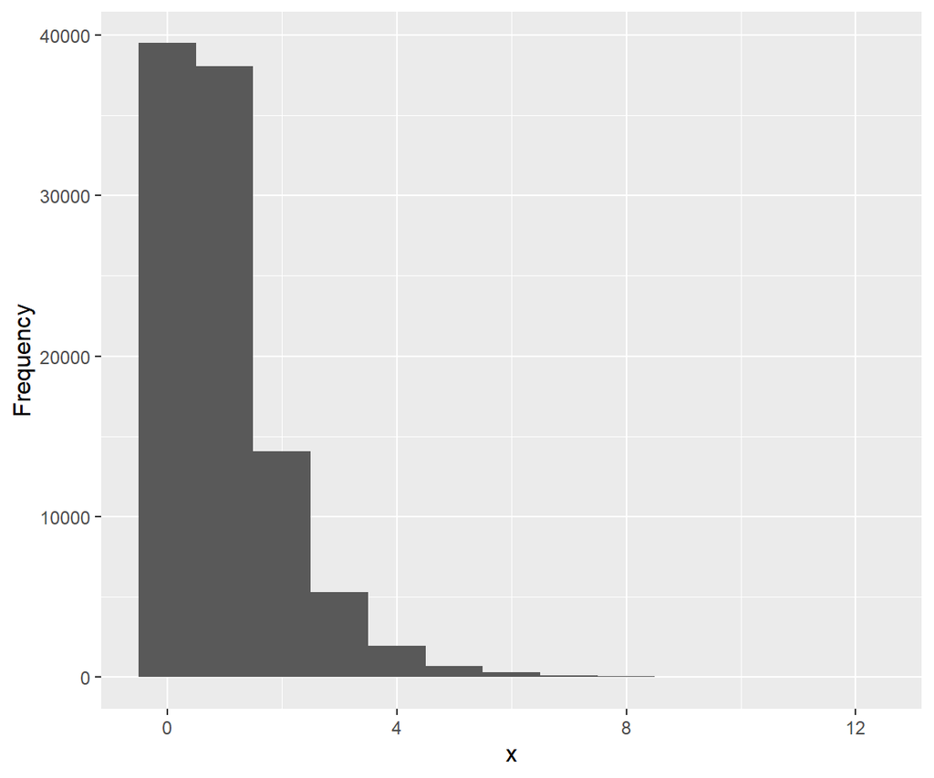

1. Describe the modality of the histogram.
2. Describe the symmetry of the histogram.
3. Describe the skewness of the histogram.

(Question ID: *0484858292*)

Consider the following histogram.

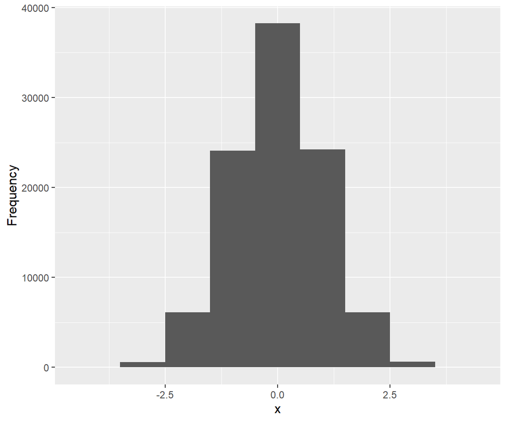

1. Describe the modality of the histogram.
2. Describe the symmetry of the histogram.
3. Describe the skewness of the histogram.

(Question ID: *0285878185*)

Consider the following histogram.

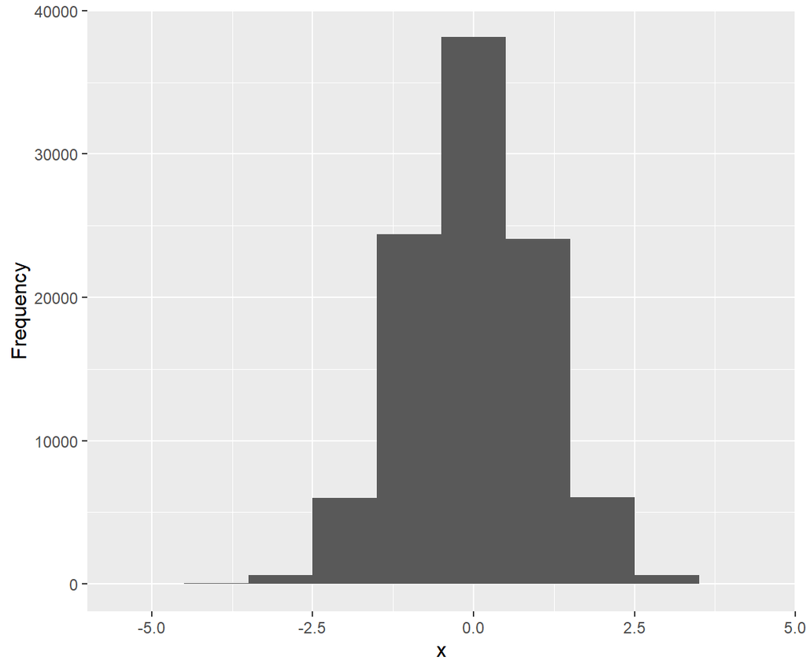

1. Describe the modality of the histogram.
2. Describe the symmetry of the histogram.
3. Describe the skewness of the histogram.

(Question ID: *0362025973*)

Consider the following histogram.

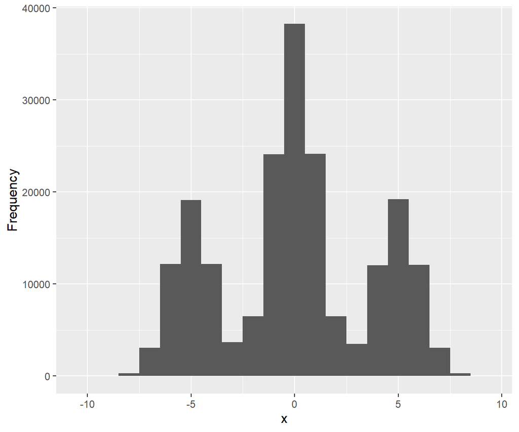

1. Describe the modality of the histogram.
2. Describe the symmetry of the histogram.
3. Describe the skewness of the histogram.

(Question ID: *0093256130*)

Consider the following histogram.

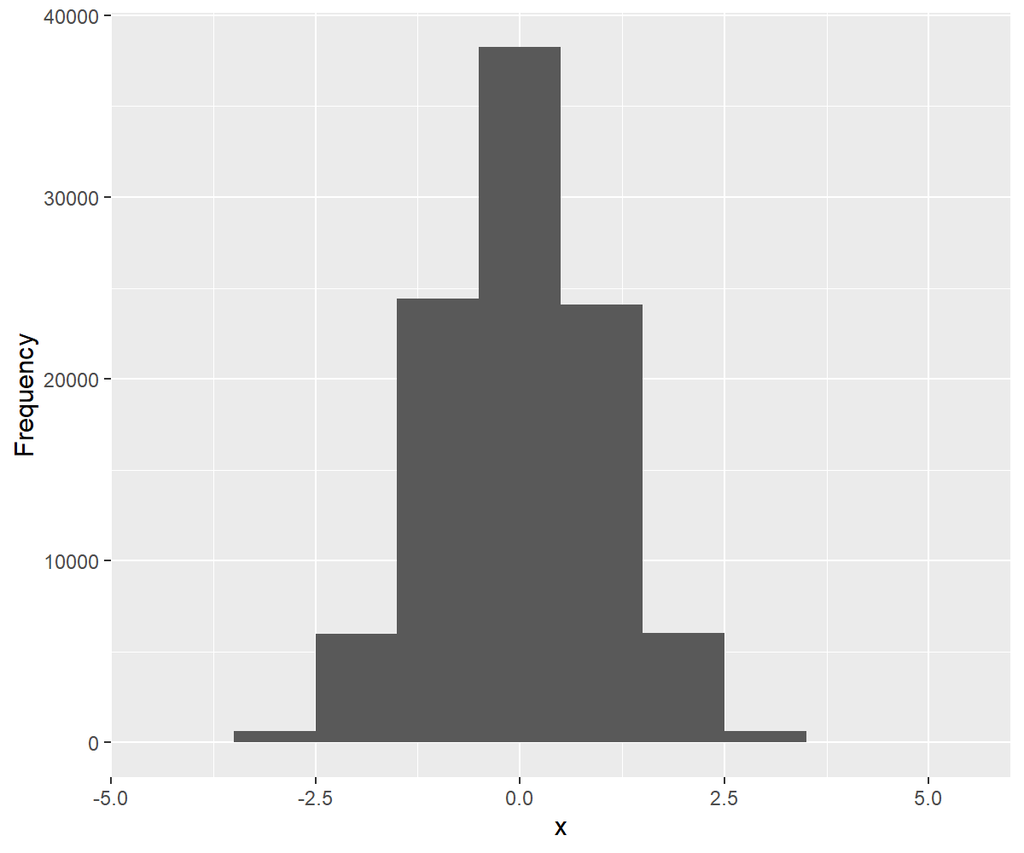

1. Describe the modality of the histogram.
2. Describe the symmetry of the histogram.
3. Describe the skewness of the histogram.

(Question ID: *0059671457*)

Consider the following histogram.

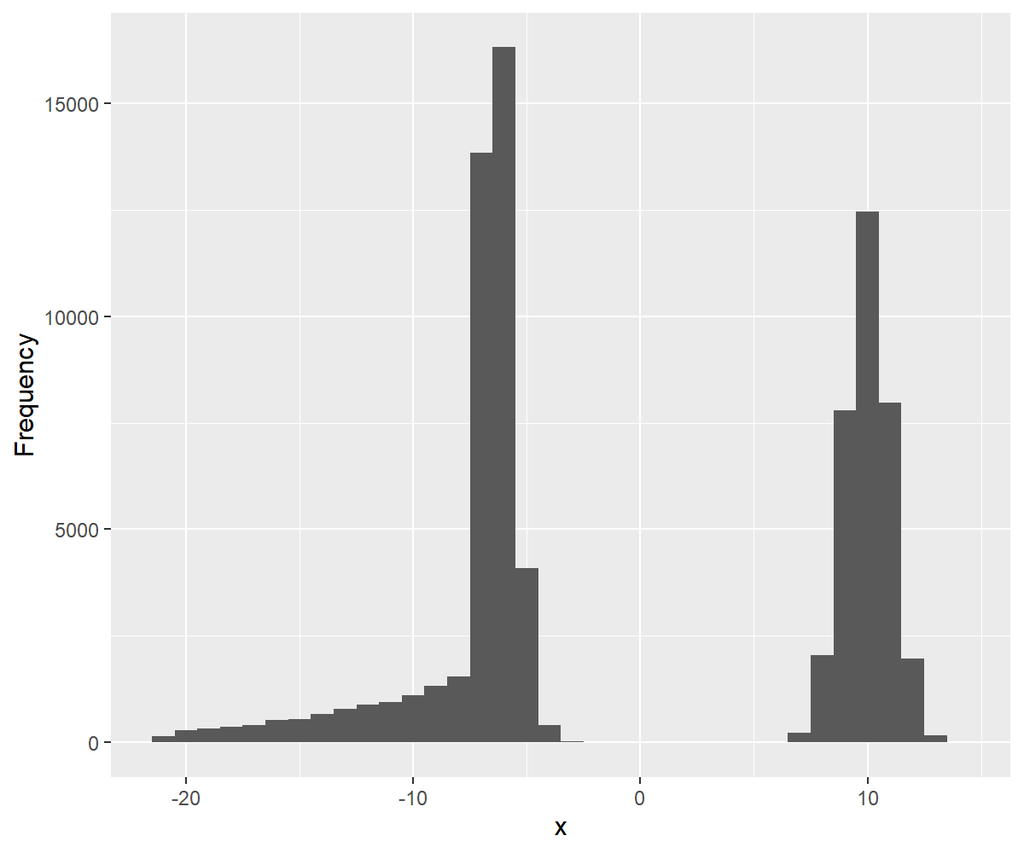

1. Describe the modality of the histogram.
2. Describe the symmetry of the histogram.
3. Describe the skewness of the histogram.

(Question ID: *0930492322*)

Consider the following histogram.

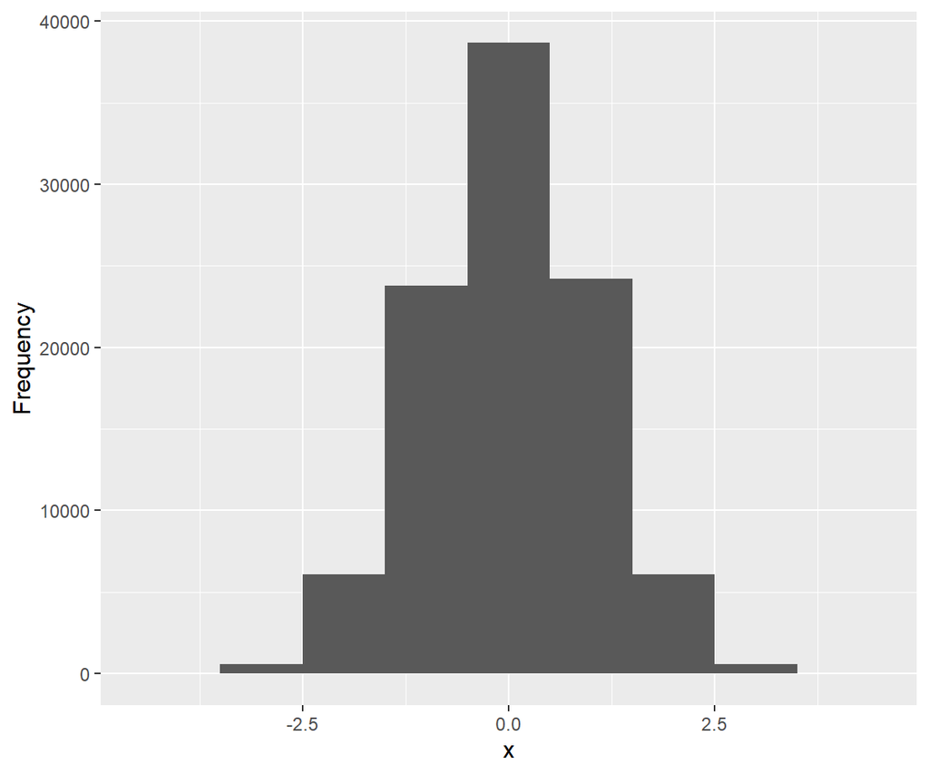

1. Describe the modality of the histogram.
2. Describe the symmetry of the histogram.
3. Describe the skewness of the histogram.

(Question ID: *0840701655*)

Consider the following histogram.

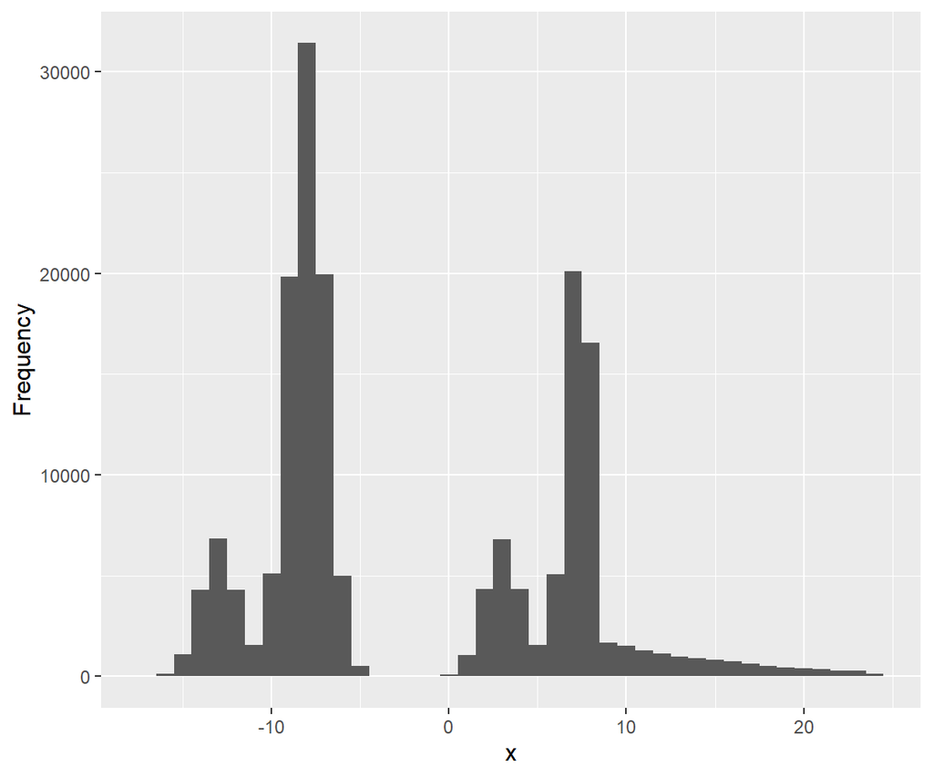

1. Describe the modality of the histogram.
2. Describe the symmetry of the histogram.
3. Describe the skewness of the histogram.

(Question ID: *0023129399*)

Consider the following histogram.

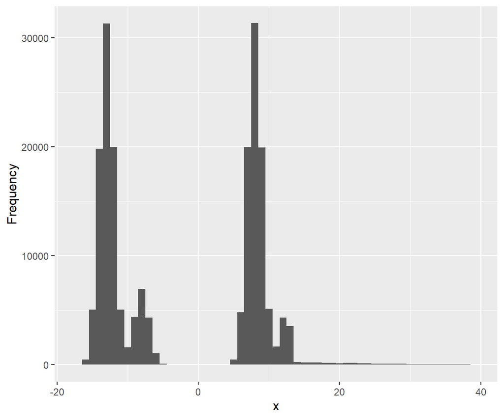

1. Describe the modality of the histogram.
2. Describe the symmetry of the histogram.
3. Describe the skewness of the histogram.

(Question ID: *0550724396*)

Consider the following histogram.

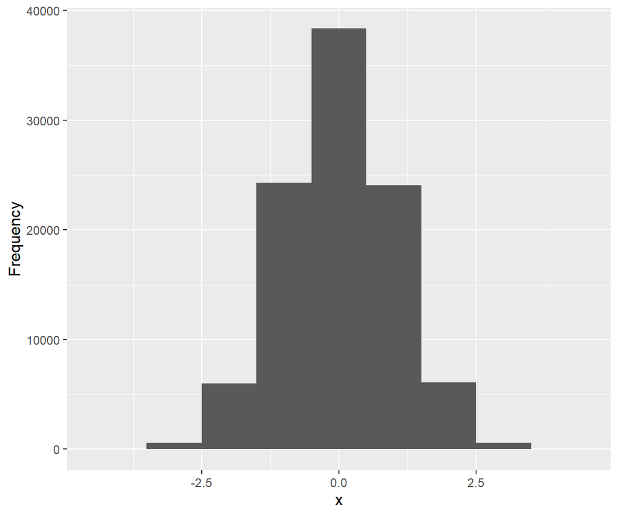

1. Describe the modality of the histogram.
2. Describe the symmetry of the histogram.
3. Describe the skewness of the histogram.

(Question ID: *0006929930*)

Consider the following histogram.

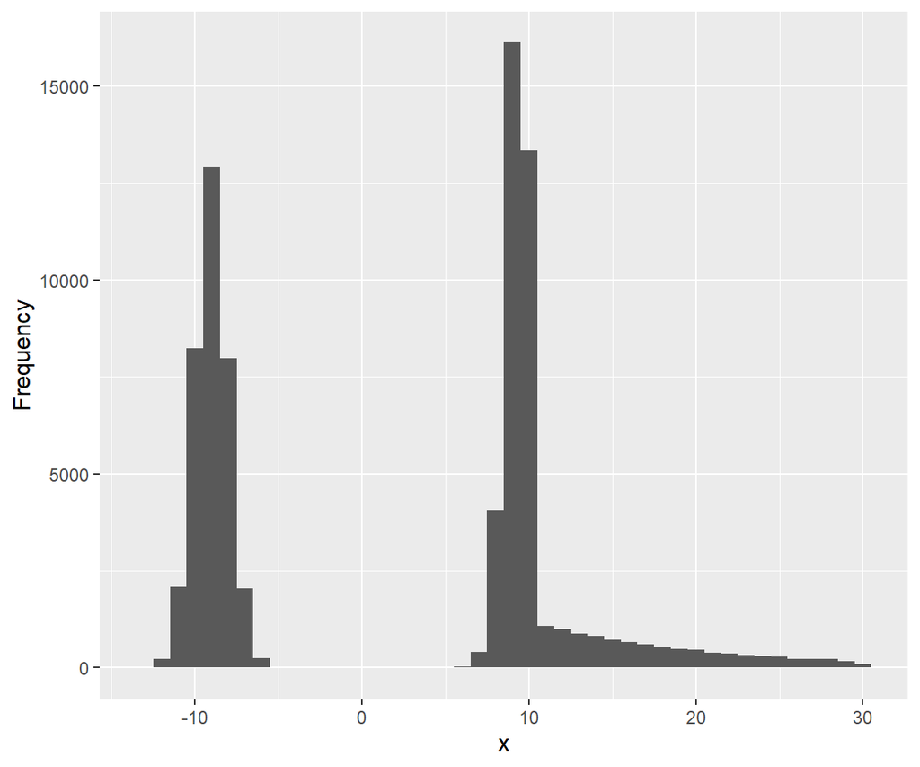

1. Describe the modality of the histogram.
2. Describe the symmetry of the histogram.
3. Describe the skewness of the histogram.

(Question ID: *0963277488*)

Consider the following histogram.

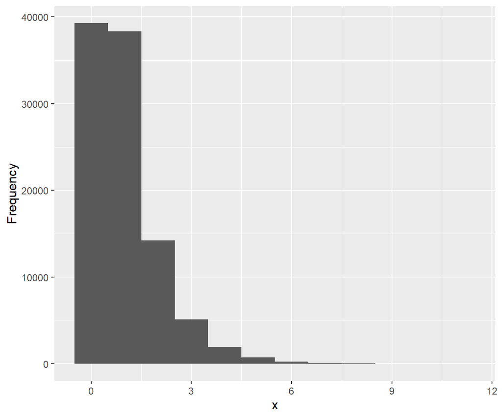

1. Describe the modality of the histogram.
2. Describe the symmetry of the histogram.
3. Describe the skewness of the histogram.

(Question ID: *0240771440*)

Consider the following histogram.

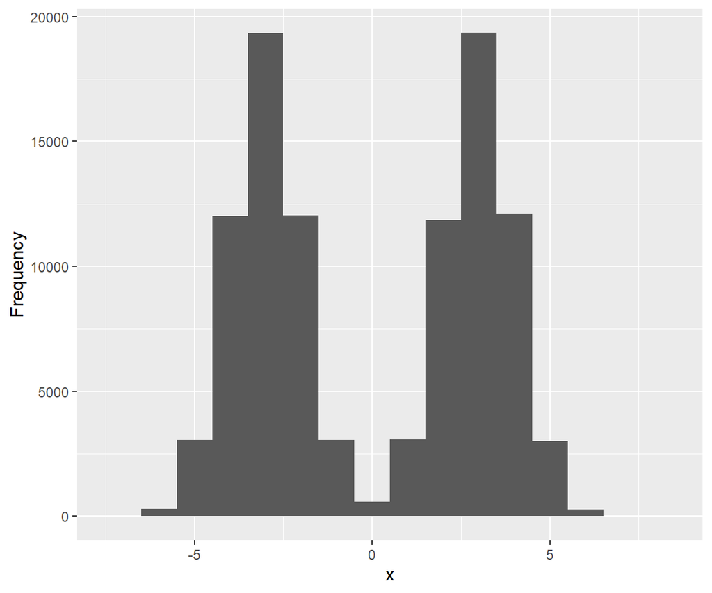

1. Describe the modality of the histogram.
2. Describe the symmetry of the histogram.
3. Describe the skewness of the histogram.

(Question ID: *0859489378*)

Consider the following histogram.

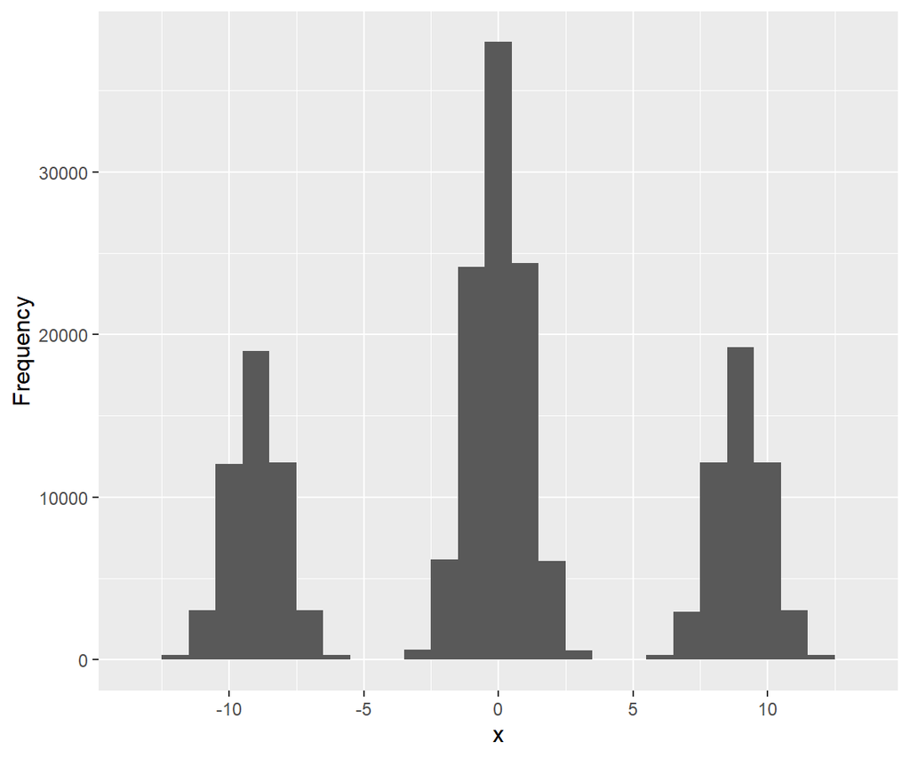

1. Describe the modality of the histogram.
2. Describe the symmetry of the histogram.
3. Describe the skewness of the histogram.

(Question ID: *0080033600*)

Consider the following histogram.

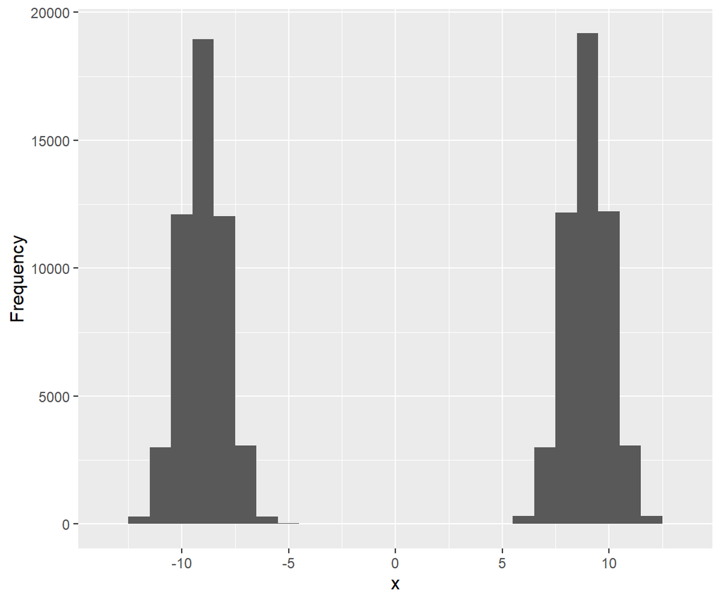

1. Describe the modality of the histogram.
2. Describe the symmetry of the histogram.
3. Describe the skewness of the histogram.

(Question ID: *0524880970*)

Consider the following histogram.

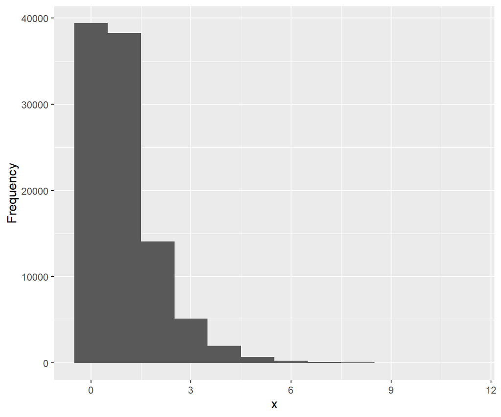

1. Describe the modality of the histogram.
2. Describe the symmetry of the histogram.
3. Describe the skewness of the histogram.

(Question ID: *0694048379*)

[^1]: To get a glimpse into the world of graphical displays of information, used both well and poorly, it is worth a scroll through of two subreddits: [/r/dataisbeautiful](https://www.reddit.com/r/dataisbeautiful/) and [/r/dataisugly](https://www.reddit.com/r/dataisugly/). While I do not universally agree with the categorization of these, a lot of the posts at least demonstrate the ways in which modern technology has expanded the potential for creativity.
[^2]: Read more about this in [this Scientific American article](https://www.scientificamerican.com/article/how-florence-nightingale-changed-data-visualization-forever/).
[^3]: Read more about this in [this brief description](https://www.mun.ca/biology/scarr/4270_Cholera_outbreak_1854.html).
[^4]: There is some indication that, while the identification of the water pump lead to it being shutoff by the city, the cases of cholera were already reducing by this point. It is thus unclear whether the intervention was timely enough to be effective. However, the impact of the finding looms large to this day.
[^5]: For instance, if you are looking at measurements of some quantity over time, time can be used as a “numeric quantity”. If the data are geographic in nature, perhaps the locations of different events, then you can use geographic location (latitude and longitude) as numeric data, to place them on a map. These two ideas have been combined to create some very effective and compelling data visualizations. Notably, *1945-1998* is a work of art by Isao Hashimoto, which shows a time lapse video of every nuclear detonation between 1945 and 1998. The video, available on [YouTube](https://www.youtube.com/watch?v=LLCF7vPanrY) can be quite affecting. It is very heavy, and while I think a phenomenal representation of the way in which data can be conveyed effectively, please only watch if you are in a position to do so.
[^6]: Recall from Section 4.5 a contingency table summarizes a frequency distribution in two or more variables.
[^7]: You can use other types of plots as well, such as pie charts. Most statisticians will be adamant in their disavowal of pie charts because they are typically pretty bad at doing what they set out to do.
[^8]: Horst AM, Hill AP, Gorman KB (2020). palmerpenguins: Palmer Archipelago (Antarctica) penguin data. R package Version 0.1.0. https://allisonhorst.github.io/palmerpenguins/. doi:11.5281/zenodo.3960218.

[figure not shown]

[^10]: Almost always.
[^11]: Again, almost always.
[^12]: Which is to say, we rely on the *vibes* of the tails, rather than their mathematical behaviour explicitly.
[^13]: For reference, NHL games are 60 minutes long (potentially longer if no one is winning at the end of the time), divided into 3 periods. When play is stopped, a face-off takes place to start the play again. Penalties occur when rules are violated by one of the teams. On the histograms, the start of the three periods are indicated in red dotted lines. These data come from a random sample of $200$ games during the 2022-2023 NHL regular season.
[^14]: This makes the sample variance **unbiased** for the true variance. If you conceive of the sample variance as a random quantity, one that depends on what sample you actually take, dividing by $n-1$ rather than by $n$ will make it so that $E[S^2] = \text{var}(X)$, where if you divide by $n$ this will not be the case.
[^15]: Outliers are a topic that necessitate a great deal of discussion to approach with care. As a general rule, I would be skeptical of any analysis you see which excludes outliers on the basis of a statistical test. Outliers, especially as assessed from these types of rules, are better understood as points that demonstrate that the data are heavy-tailed rather than points which should be ignored.